# Predicting Minutes Played In The NBA

## Background & Motivations

- We hope to predict minutes played through other types of basketball statistics.
- Minutes played is valuable to keep track of because more minutes played will offer a player more opportunities to contribute to the game.
- We looked at statistics from the 2018-2019 NBA season for players who played in at least 41 games, or half the season.
- We converted counting stats (eg rebounds) into per 36 minute rates. These rates can provide a good insight into a player’s productivity without interference from the number of minutes played by the player.

## Kernel Density Estimation

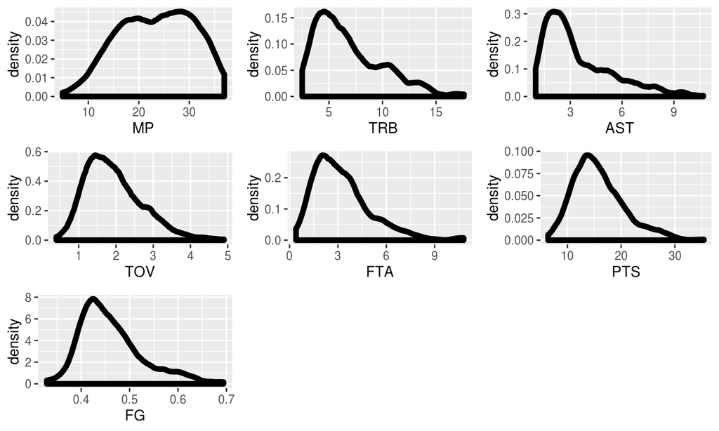

## Scatterplots

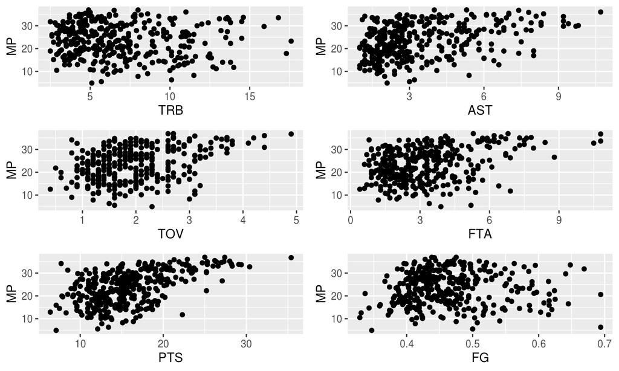

## OLS Multiple Linear Regression

|  | Predictor | P-Value |
| --- | --- | --- |
| (Intercept) | 9.5726 | 0.0006 |
| TRB | -0.0525 | 0.7443 |
| AST | 1.1850 | 0.0000 |
| TOV | -1.8836 | 0.0152 |
| FTA | -0.3123 | 0.3291 |
| PTS | 0.9633 | 0.0000 |
| FG | -0.9236 | 0.8925 |

MP = 9.573 - 0.052 TRB + 1.185 AST - 1.884 TOV - 0.312 FTA + 0.963 PTS - 0.924 FG

## Bootstrap

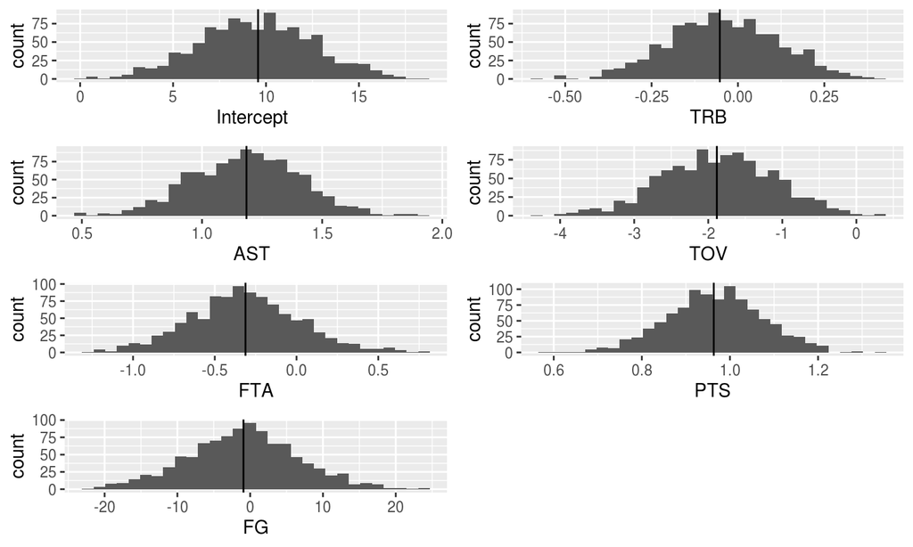

## OLS Multiple Linear Regression

|  | Predictor | P-Value |
| --- | --- | --- |
| (Intercept) | 9.3395 | 0.0000 |
| AST | 1.2937 | 0.0000 |
| TOV | -2.3198 | 0.0006 |
| PTS | 0.8941 | 0.0000 |

## JHM Multiple Regression

|  | Predictor | P-Value |
| --- | --- | --- |
| (Intercept) | 9.2974 | 0.0014 |
| TRB | -0.0900 | 0.5899 |
| AST | 1.1754 | 0.0000 |
| TOV | -1.7629 | 0.0285 |
| FTA | -0.3651 | 0.2717 |
| PTS | 0.9870 | 0.0000 |
| FG | 0.3390 | 0.9619 |

MP = 9.294 - 0.090 TRB + 1.176 AST - 1.764 TOV - 0.365 FTA + 0.987 PTS + 0.341 FG

## JHM Multiple Regression

|  | Predictor | P-Value |
| --- | --- | --- |
| (Intercept) | 9.4232 | 0.0000 |
| AST | 1.2995 | 0.0000 |
| TOV | -2.2717 | 0.0011 |
| PTS | 0.9083 | 0.0000 |

## Generalized Additive Model

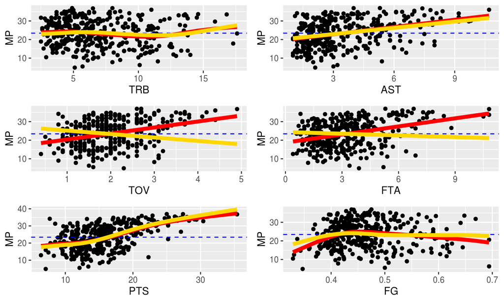

AIC: 2221.5334353

## Generalized Additive Model

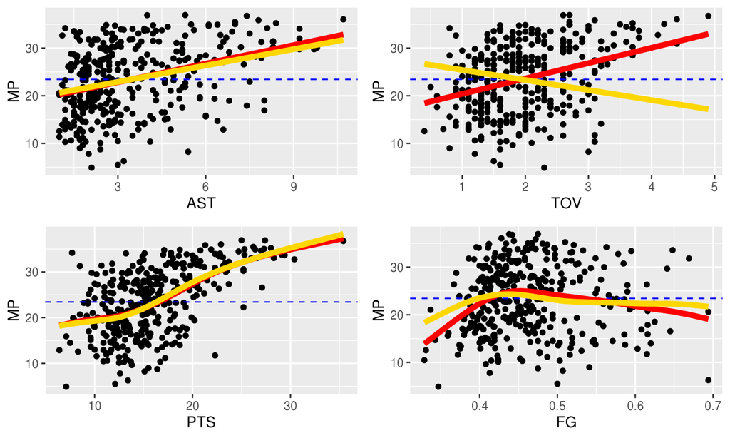

AIC: 2219.0000079

## Residual Plots

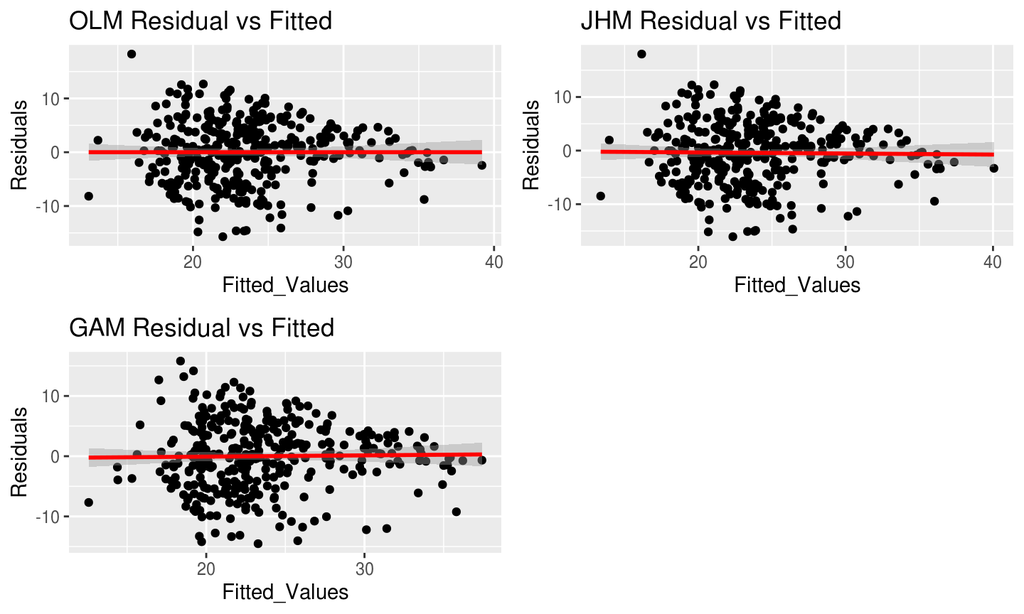

## Kolmogorov Smirnov Test

| OLS | 0.6180 |
| --- | --- |
| JHM | 0.5161 |
| GAM | 0.5161 |

Not enough evidence to say the residual distributions stray from Normal.

## Model Fit CV (Both Models)

|  | cv.rsq | cv.adjrsq | cv.propL1 |
| --- | --- | --- | --- |
| OLS | 0.3365 | 0.3248 | 0.2344 |
| JHM | 0.3346 | 0.3229 | 0.2371 |
| GAM | 0.3422 | 0.3126 | 0.2481 |

|  | cv.rsq | cv.adjrsq | cv.propL1 |
| --- | --- | --- | --- |
| OLS | 0.3421 | 0.3364 | 0.2356 |
| JHM | 0.3381 | 0.3323 | 0.2356 |
| GAM | 0.3447 | 0.3253 | 0.2512 |

## Model Fit and CV (Reduced Models)

|  | rsq | adjrsq | propL1 |
| --- | --- | --- | --- |
| OLS | 0.3586 | 0.3530 | 0.2446 |
| JHM | 0.3550 | 0.3494 | 0.2473 |
| GAM | 0.3961 | 0.3782 | 0.2787 |

|  | cv.rsq | cv.adjrsq | cv.propL1 |
| --- | --- | --- | --- |
| OLS | 0.3447 | 0.3390 | 0.2357 |
| JHM | 0.3401 | 0.3344 | 0.2360 |
| GAM | 0.3491 | 0.3299 | 0.2532 |

## Takeaways

- Raw box score numbers do not do a good job of predicting the number of minutes played
- The models tested seem to have similar values for \(R^2\), \(Adj R^2\), and \(L1_{prop}\).
- Future studies could examine different models for different positions, the usage of other stats, or different filtering conditions